# Risk Factor Analysis

## Outcome Variable

**Outcome Variable:** sstunted

## Predictor Variables

**Intervention Variable:** anywast06

**Adjustment Set:**

unadjusted

## Stratifying Variables

The analysis was stratified on these variable(s):

- agecat
- studyid
- country

## Data Summary

| agecat | studyid | country | anywast06 | sstunted | n_cell | n |
| --- | --- | --- | --- | --- | --- | --- |
| Birth | ki0047075b-MAL-ED | BANGLADESH | 0 | 0 | 191 | 255 |
| Birth | ki0047075b-MAL-ED | BANGLADESH | 0 | 1 | 7 | 255 |
| Birth | ki0047075b-MAL-ED | BANGLADESH | 1 | 0 | 55 | 255 |
| Birth | ki0047075b-MAL-ED | BANGLADESH | 1 | 1 | 2 | 255 |
| Birth | ki0047075b-MAL-ED | BRAZIL | 0 | 0 | 170 | 191 |
| Birth | ki0047075b-MAL-ED | BRAZIL | 0 | 1 | 8 | 191 |
| Birth | ki0047075b-MAL-ED | BRAZIL | 1 | 0 | 13 | 191 |
| Birth | ki0047075b-MAL-ED | BRAZIL | 1 | 1 | 0 | 191 |
| Birth | ki0047075b-MAL-ED | INDIA | 0 | 0 | 139 | 206 |
| Birth | ki0047075b-MAL-ED | INDIA | 0 | 1 | 5 | 206 |
| Birth | ki0047075b-MAL-ED | INDIA | 1 | 0 | 60 | 206 |
| Birth | ki0047075b-MAL-ED | INDIA | 1 | 1 | 2 | 206 |
| Birth | ki0047075b-MAL-ED | NEPAL | 0 | 0 | 137 | 173 |
| Birth | ki0047075b-MAL-ED | NEPAL | 0 | 1 | 4 | 173 |
| Birth | ki0047075b-MAL-ED | NEPAL | 1 | 0 | 30 | 173 |
| Birth | ki0047075b-MAL-ED | NEPAL | 1 | 1 | 2 | 173 |
| Birth | ki0047075b-MAL-ED | PERU | 0 | 0 | 268 | 286 |
| Birth | ki0047075b-MAL-ED | PERU | 0 | 1 | 7 | 286 |
| Birth | ki0047075b-MAL-ED | PERU | 1 | 0 | 11 | 286 |
| Birth | ki0047075b-MAL-ED | PERU | 1 | 1 | 0 | 286 |
| Birth | ki0047075b-MAL-ED | SOUTH AFRICA | 0 | 0 | 229 | 261 |
| Birth | ki0047075b-MAL-ED | SOUTH AFRICA | 0 | 1 | 1 | 261 |
| Birth | ki0047075b-MAL-ED | SOUTH AFRICA | 1 | 0 | 31 | 261 |
| Birth | ki0047075b-MAL-ED | SOUTH AFRICA | 1 | 1 | 0 | 261 |
| Birth | ki0047075b-MAL-ED | TANZANIA, UNITED REPUBLIC OF | 0 | 0 | 111 | 123 |
| Birth | ki0047075b-MAL-ED | TANZANIA, UNITED REPUBLIC OF | 0 | 1 | 6 | 123 |
| Birth | ki0047075b-MAL-ED | TANZANIA, UNITED REPUBLIC OF | 1 | 0 | 6 | 123 |
| Birth | ki0047075b-MAL-ED | TANZANIA, UNITED REPUBLIC OF | 1 | 1 | 0 | 123 |
| Birth | ki1000108-CMC-V-BCS-2002 | INDIA | 0 | 0 | 36 | 90 |
| Birth | ki1000108-CMC-V-BCS-2002 | INDIA | 0 | 1 | 0 | 90 |

[output cut: 170 more lines]

The following strata were considered:

- agecat: 24 months, studyid: ki0047075b-MAL-ED, country: BANGLADESH
- agecat: 24 months, studyid: ki0047075b-MAL-ED, country: BRAZIL
- agecat: 24 months, studyid: ki0047075b-MAL-ED, country: INDIA
- agecat: 24 months, studyid: ki0047075b-MAL-ED, country: NEPAL
- agecat: 24 months, studyid: ki0047075b-MAL-ED, country: PERU
- agecat: 24 months, studyid: ki0047075b-MAL-ED, country: SOUTH AFRICA
- agecat: 24 months, studyid: ki0047075b-MAL-ED, country: TANZANIA, UNITED REPUBLIC OF
- agecat: 24 months, studyid: ki1000108-CMC-V-BCS-2002, country: INDIA
- agecat: 24 months, studyid: ki1000108-IRC, country: INDIA
- agecat: 24 months, studyid: ki1017093b-PROVIDE, country: BANGLADESH
- agecat: 24 months, studyid: ki1066203-TanzaniaChild2, country: TANZANIA, UNITED REPUBLIC OF
- agecat: 24 months, studyid: ki1101329-Keneba, country: GAMBIA
- agecat: 24 months, studyid: ki1113344-GMS-Nepal, country: NEPAL
- agecat: 24 months, studyid: ki1114097-CMIN, country: BANGLADESH
- agecat: 24 months, studyid: ki1114097-CMIN, country: PERU
- agecat: 24 months, studyid: ki1114097-CONTENT, country: PERU
- agecat: 6 months, studyid: ki0047075b-MAL-ED, country: BANGLADESH
- agecat: 6 months, studyid: ki0047075b-MAL-ED, country: BRAZIL
- agecat: 6 months, studyid: ki0047075b-MAL-ED, country: INDIA
- agecat: 6 months, studyid: ki0047075b-MAL-ED, country: NEPAL
- agecat: 6 months, studyid: ki0047075b-MAL-ED, country: PERU
- agecat: 6 months, studyid: ki0047075b-MAL-ED, country: SOUTH AFRICA
- agecat: 6 months, studyid: ki0047075b-MAL-ED, country: TANZANIA, UNITED REPUBLIC OF
- agecat: 6 months, studyid: ki1000108-CMC-V-BCS-2002, country: INDIA
- agecat: 6 months, studyid: ki1000108-IRC, country: INDIA
- agecat: 6 months, studyid: ki1000109-EE, country: PAKISTAN
- agecat: 6 months, studyid: ki1000109-ResPak, country: PAKISTAN
- agecat: 6 months, studyid: ki1017093b-PROVIDE, country: BANGLADESH
- agecat: 6 months, studyid: ki1066203-TanzaniaChild2, country: TANZANIA, UNITED REPUBLIC OF
- agecat: 6 months, studyid: ki1101329-Keneba, country: GAMBIA
- agecat: 6 months, studyid: ki1112895-Guatemala BSC, country: GUATEMALA
- agecat: 6 months, studyid: ki1113344-GMS-Nepal, country: NEPAL
- agecat: 6 months, studyid: ki1114097-CMIN, country: BANGLADESH
- agecat: 6 months, studyid: ki1114097-CMIN, country: PERU
- agecat: 6 months, studyid: ki1114097-CONTENT, country: PERU
- agecat: Birth, studyid: ki0047075b-MAL-ED, country: BANGLADESH
- agecat: Birth, studyid: ki0047075b-MAL-ED, country: BRAZIL
- agecat: Birth, studyid: ki0047075b-MAL-ED, country: INDIA
- agecat: Birth, studyid: ki0047075b-MAL-ED, country: NEPAL
- agecat: Birth, studyid: ki0047075b-MAL-ED, country: PERU
- agecat: Birth, studyid: ki0047075b-MAL-ED, country: SOUTH AFRICA
- agecat: Birth, studyid: ki0047075b-MAL-ED, country: TANZANIA, UNITED REPUBLIC OF
- agecat: Birth, studyid: ki1000108-CMC-V-BCS-2002, country: INDIA
- agecat: Birth, studyid: ki1000108-IRC, country: INDIA
- agecat: Birth, studyid: ki1000109-EE, country: PAKISTAN
- agecat: Birth, studyid: ki1000109-ResPak, country: PAKISTAN
- agecat: Birth, studyid: ki1101329-Keneba, country: GAMBIA
- agecat: Birth, studyid: ki1114097-CMIN, country: BANGLADESH
- agecat: Birth, studyid: ki1114097-CMIN, country: PERU
- agecat: Birth, studyid: ki1114097-CONTENT, country: PERU

### Dropped Strata

Some strata were dropped due to rare outcomes:

- agecat: Birth, studyid: ki0047075b-MAL-ED, country: BANGLADESH
- agecat: Birth, studyid: ki0047075b-MAL-ED, country: BRAZIL
- agecat: Birth, studyid: ki0047075b-MAL-ED, country: INDIA
- agecat: Birth, studyid: ki0047075b-MAL-ED, country: NEPAL
- agecat: Birth, studyid: ki0047075b-MAL-ED, country: PERU
- agecat: Birth, studyid: ki0047075b-MAL-ED, country: SOUTH AFRICA
- agecat: Birth, studyid: ki0047075b-MAL-ED, country: TANZANIA, UNITED REPUBLIC OF
- agecat: Birth, studyid: ki1000108-CMC-V-BCS-2002, country: INDIA
- agecat: Birth, studyid: ki1000109-EE, country: PAKISTAN
- agecat: Birth, studyid: ki1000109-ResPak, country: PAKISTAN
- agecat: Birth, studyid: ki1114097-CMIN, country: BANGLADESH
- agecat: Birth, studyid: ki1114097-CMIN, country: PERU
- agecat: Birth, studyid: ki1114097-CONTENT, country: PERU
- agecat: 6 months, studyid: ki0047075b-MAL-ED, country: BANGLADESH
- agecat: 6 months, studyid: ki0047075b-MAL-ED, country: BRAZIL
- agecat: 6 months, studyid: ki0047075b-MAL-ED, country: INDIA
- agecat: 6 months, studyid: ki0047075b-MAL-ED, country: NEPAL
- agecat: 6 months, studyid: ki0047075b-MAL-ED, country: PERU
- agecat: 6 months, studyid: ki0047075b-MAL-ED, country: SOUTH AFRICA
- agecat: 6 months, studyid: ki0047075b-MAL-ED, country: TANZANIA, UNITED REPUBLIC OF
- agecat: 6 months, studyid: ki1066203-TanzaniaChild2, country: TANZANIA, UNITED REPUBLIC OF
- agecat: 6 months, studyid: ki1112895-Guatemala BSC, country: GUATEMALA
- agecat: 6 months, studyid: ki1114097-CMIN, country: PERU
- agecat: 6 months, studyid: ki1114097-CONTENT, country: PERU
- agecat: 24 months, studyid: ki0047075b-MAL-ED, country: BRAZIL
- agecat: 24 months, studyid: ki0047075b-MAL-ED, country: NEPAL
- agecat: 24 months, studyid: ki0047075b-MAL-ED, country: PERU
- agecat: 24 months, studyid: ki0047075b-MAL-ED, country: SOUTH AFRICA
- agecat: 24 months, studyid: ki0047075b-MAL-ED, country: TANZANIA, UNITED REPUBLIC OF
- agecat: 24 months, studyid: ki1066203-TanzaniaChild2, country: TANZANIA, UNITED REPUBLIC OF
- agecat: 24 months, studyid: ki1114097-CMIN, country: PERU
- agecat: 24 months, studyid: ki1114097-CONTENT, country: PERU

## Methods Detail

We’re interested in the causal parameters $E[Y_a]$ for all values of $a \in \mathcal{A}$. These parameters represent the mean outcome if, possibly contrary to fact, we intervened to set all units to have $A=a$. Under the randomization and positivity assumptions, these are identified by the statistical parameters $\psi_a=E_W[E_{Y|A,W}(Y|A=a,W)]$. In addition, we’re interested in the mean of $Y$, $E[Y]$ under no intervention (the observed mean). We will estimate these parameters by using SuperLearner to fit the relevant likelihood factors – $E_{Y|A,W}(Y|A=a,W)$ and $p(A=a|W)$, and then updating our likelihood fit using a joint TMLE.

For unadjusted analyses ($W=\{\}$), initial likelihoods were estimated using Lrnr_glm to estimate the simple $E(Y|A)$ and Lrnr_mean to estimate $p(A)$. For adjusted analyses, a small library containing Lrnr_glmnet, Lrnr_xgboost, and Lrnr_mean was used.

Having estimated these parameters, we will then use the delta method to estimate relative risks and attributable risks relative to a prespecified baseline level of $A$.

# Results Detail

## Results Plots

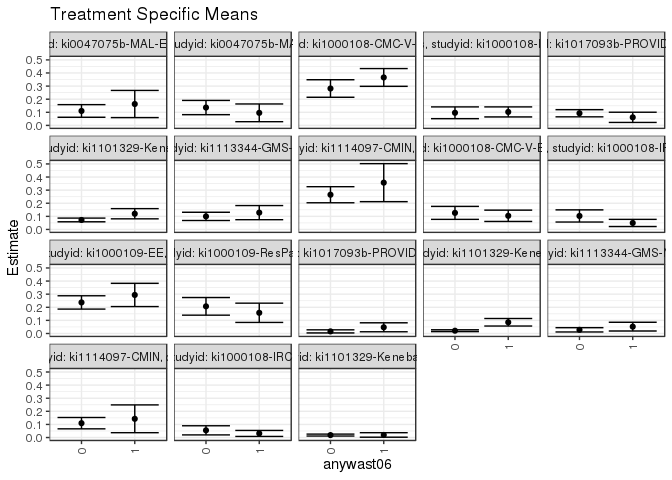

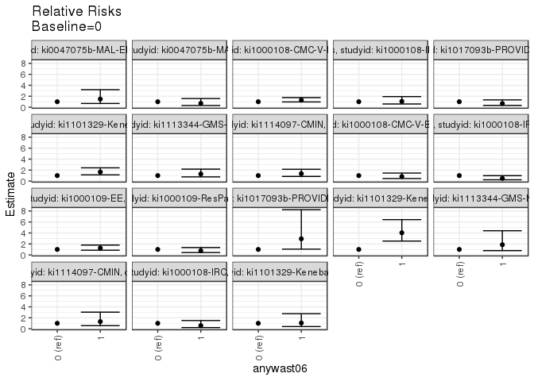

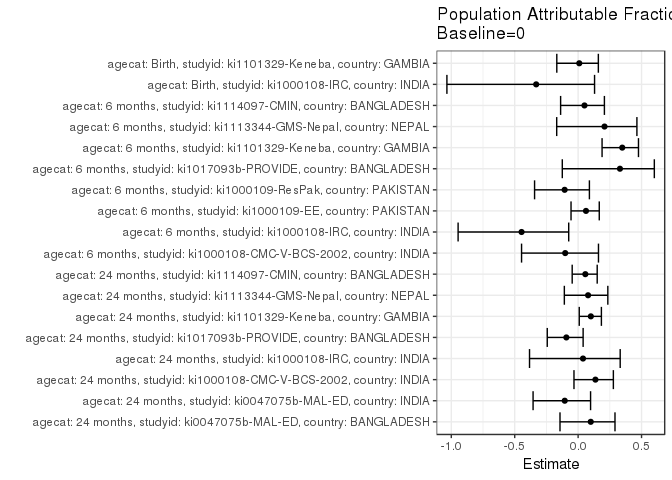

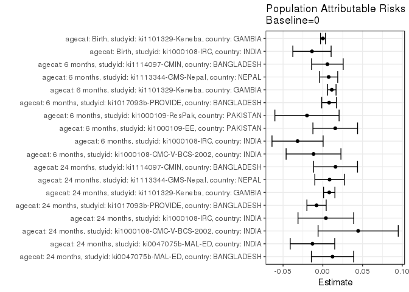

## Results Table

### Parameter: TSM

| agecat | studyid | country | intervention_level | baseline_level | estimate | ci_lower | ci_upper |
| --- | --- | --- | --- | --- | --- | --- | --- |
| Birth | ki1000108-IRC | INDIA | 0 | NA | 0.0548780 | 0.0199777 | 0.0897784 |
| Birth | ki1000108-IRC | INDIA | 1 | NA | 0.0312500 | 0.0084353 | 0.0540647 |
| Birth | ki1101329-Keneba | GAMBIA | 0 | NA | 0.0186480 | 0.0112549 | 0.0260412 |
| Birth | ki1101329-Keneba | GAMBIA | 1 | NA | 0.0196850 | 0.0025958 | 0.0367743 |
| 6 months | ki1000108-CMC-V-BCS-2002 | INDIA | 0 | NA | 0.1264368 | 0.0769885 | 0.1758851 |
| 6 months | ki1000108-CMC-V-BCS-2002 | INDIA | 1 | NA | 0.1041667 | 0.0608984 | 0.1474349 |
| 6 months | ki1000108-IRC | INDIA | 0 | NA | 0.1030303 | 0.0565882 | 0.1494724 |
| 6 months | ki1000108-IRC | INDIA | 1 | NA | 0.0495868 | 0.0222017 | 0.0769718 |
| 6 months | ki1000109-EE | PAKISTAN | 0 | NA | 0.2370370 | 0.1862433 | 0.2878308 |
| 6 months | ki1000109-EE | PAKISTAN | 1 | NA | 0.2941176 | 0.2055736 | 0.3826617 |
| 6 months | ki1000109-ResPak | PAKISTAN | 0 | NA | 0.2071429 | 0.1398696 | 0.2744161 |
| 6 months | ki1000109-ResPak | PAKISTAN | 1 | NA | 0.1578947 | 0.0844130 | 0.2313765 |
| 6 months | ki1017093b-PROVIDE | BANGLADESH | 0 | NA | 0.0160920 | 0.0042572 | 0.0279267 |
| 6 months | ki1017093b-PROVIDE | BANGLADESH | 1 | NA | 0.0472973 | 0.0130689 | 0.0815257 |
| 6 months | ki1101329-Keneba | GAMBIA | 0 | NA | 0.0212389 | 0.0143734 | 0.0281045 |
| 6 months | ki1101329-Keneba | GAMBIA | 1 | NA | 0.0856354 | 0.0568026 | 0.1144681 |
| 6 months | ki1113344-GMS-Nepal | NEPAL | 0 | NA | 0.0281330 | 0.0117287 | 0.0445373 |
| 6 months | ki1113344-GMS-Nepal | NEPAL | 1 | NA | 0.0523256 | 0.0190170 | 0.0856342 |
| 6 months | ki1114097-CMIN | BANGLADESH | 0 | NA | 0.1094527 | 0.0662026 | 0.1527029 |
| 6 months | ki1114097-CMIN | BANGLADESH | 1 | NA | 0.1428571 | 0.0368106 | 0.2489037 |
| 24 months | ki0047075b-MAL-ED | BANGLADESH | 0 | NA | 0.1104294 | 0.0621999 | 0.1586590 |
| 24 months | ki0047075b-MAL-ED | BANGLADESH | 1 | NA | 0.1632653 | 0.0595321 | 0.2669985 |
| 24 months | ki0047075b-MAL-ED | INDIA | 0 | NA | 0.1363636 | 0.0820435 | 0.1906838 |
| 24 months | ki0047075b-MAL-ED | INDIA | 1 | NA | 0.0958904 | 0.0281975 | 0.1635834 |
| 24 months | ki1000108-CMC-V-BCS-2002 | INDIA | 0 | NA | 0.2816092 | 0.2146873 | 0.3485311 |
| 24 months | ki1000108-CMC-V-BCS-2002 | INDIA | 1 | NA | 0.3659794 | 0.2981031 | 0.4338557 |
| 24 months | ki1000108-IRC | INDIA | 0 | NA | 0.0963855 | 0.0514362 | 0.1413349 |
| 24 months | ki1000108-IRC | INDIA | 1 | NA | 0.1028807 | 0.0646362 | 0.1411251 |
| 24 months | ki1017093b-PROVIDE | BANGLADESH | 0 | NA | 0.0928074 | 0.0653900 | 0.1202249 |
| 24 months | ki1017093b-PROVIDE | BANGLADESH | 1 | NA | 0.0616438 | 0.0225978 | 0.1006899 |
| 24 months | ki1101329-Keneba | GAMBIA | 0 | NA | 0.0724749 | 0.0583602 | 0.0865897 |
| 24 months | ki1101329-Keneba | GAMBIA | 1 | NA | 0.1198502 | 0.0808803 | 0.1588201 |
| 24 months | ki1113344-GMS-Nepal | NEPAL | 0 | NA | 0.0997151 | 0.0683389 | 0.1310913 |
| 24 months | ki1113344-GMS-Nepal | NEPAL | 1 | NA | 0.1283784 | 0.0744319 | 0.1823248 |
| 24 months | ki1114097-CMIN | BANGLADESH | 0 | NA | 0.2650000 | 0.2037087 | 0.3262913 |
| 24 months | ki1114097-CMIN | BANGLADESH | 1 | NA | 0.3571429 | 0.2119314 | 0.5023543 |

### Parameter: E(Y)

| agecat | studyid | country | intervention_level | baseline_level | estimate | ci_lower | ci_upper |
| --- | --- | --- | --- | --- | --- | --- | --- |
| Birth | ki1000108-IRC | INDIA | NA | NA | 0.0412371 | 0.0214268 | 0.0610475 |
| Birth | ki1101329-Keneba | GAMBIA | NA | NA | 0.0188189 | 0.0120322 | 0.0256057 |
| 6 months | ki1000108-CMC-V-BCS-2002 | INDIA | NA | NA | 0.1147541 | 0.0820564 | 0.1474518 |
| 6 months | ki1000108-IRC | INDIA | NA | NA | 0.0712531 | 0.0462303 | 0.0962759 |
| 6 months | ki1000109-EE | PAKISTAN | NA | NA | 0.2526882 | 0.2084696 | 0.2969067 |
| 6 months | ki1000109-ResPak | PAKISTAN | NA | NA | 0.1872340 | 0.1372518 | 0.2372162 |
| 6 months | ki1017093b-PROVIDE | BANGLADESH | NA | NA | 0.0240137 | 0.0115761 | 0.0364514 |
| 6 months | ki1101329-Keneba | GAMBIA | NA | NA | 0.0325717 | 0.0248987 | 0.0402447 |
| 6 months | ki1113344-GMS-Nepal | NEPAL | NA | NA | 0.0355240 | 0.0202206 | 0.0508273 |
| 6 months | ki1114097-CMIN | BANGLADESH | NA | NA | 0.1152263 | 0.0749980 | 0.1554547 |
| 24 months | ki0047075b-MAL-ED | BANGLADESH | NA | NA | 0.1226415 | 0.0783812 | 0.1669018 |
| 24 months | ki0047075b-MAL-ED | INDIA | NA | NA | 0.1233480 | 0.0804760 | 0.1662200 |
| 24 months | ki1000108-CMC-V-BCS-2002 | INDIA | NA | NA | 0.3260870 | 0.2781265 | 0.3740475 |
| 24 months | ki1000108-IRC | INDIA | NA | NA | 0.1002445 | 0.0711031 | 0.1293859 |
| 24 months | ki1017093b-PROVIDE | BANGLADESH | NA | NA | 0.0849220 | 0.0621566 | 0.1076874 |
| 24 months | ki1101329-Keneba | GAMBIA | NA | NA | 0.0805627 | 0.0670700 | 0.0940553 |
| 24 months | ki1113344-GMS-Nepal | NEPAL | NA | NA | 0.1082164 | 0.0809323 | 0.1355005 |
| 24 months | ki1114097-CMIN | BANGLADESH | NA | NA | 0.2809917 | 0.2242434 | 0.3377401 |

### Parameter: RR

| agecat | studyid | country | intervention_level | baseline_level | estimate | ci_lower | ci_upper |
| --- | --- | --- | --- | --- | --- | --- | --- |
| Birth | ki1000108-IRC | INDIA | 0 | 0 | 1.0000000 | 1.0000000 | 1.0000000 |
| Birth | ki1000108-IRC | INDIA | 1 | 0 | 0.5694444 | 0.2162511 | 1.4994928 |
| Birth | ki1101329-Keneba | GAMBIA | 0 | 0 | 1.0000000 | 1.0000000 | 1.0000000 |
| Birth | ki1101329-Keneba | GAMBIA | 1 | 0 | 1.0556102 | 0.4064649 | 2.7414740 |
| 6 months | ki1000108-CMC-V-BCS-2002 | INDIA | 0 | 0 | 1.0000000 | 1.0000000 | 1.0000000 |
| 6 months | ki1000108-CMC-V-BCS-2002 | INDIA | 1 | 0 | 0.8238636 | 0.4656753 | 1.4575636 |
| 6 months | ki1000108-IRC | INDIA | 0 | 0 | 1.0000000 | 1.0000000 | 1.0000000 |
| 6 months | ki1000108-IRC | INDIA | 1 | 0 | 0.4812834 | 0.2359422 | 0.9817394 |
| 6 months | ki1000109-EE | PAKISTAN | 0 | 0 | 1.0000000 | 1.0000000 | 1.0000000 |
| 6 months | ki1000109-EE | PAKISTAN | 1 | 0 | 1.2408088 | 0.8574756 | 1.7955107 |
| 6 months | ki1000109-ResPak | PAKISTAN | 0 | 0 | 1.0000000 | 1.0000000 | 1.0000000 |
| 6 months | ki1000109-ResPak | PAKISTAN | 1 | 0 | 0.7622505 | 0.4321510 | 1.3444971 |
| 6 months | ki1017093b-PROVIDE | BANGLADESH | 0 | 0 | 1.0000000 | 1.0000000 | 1.0000000 |
| 6 months | ki1017093b-PROVIDE | BANGLADESH | 1 | 0 | 2.9391892 | 1.0474302 | 8.2476460 |
| 6 months | ki1101329-Keneba | GAMBIA | 0 | 0 | 1.0000000 | 1.0000000 | 1.0000000 |
| 6 months | ki1101329-Keneba | GAMBIA | 1 | 0 | 4.0319981 | 2.5282182 | 6.4302238 |
| 6 months | ki1113344-GMS-Nepal | NEPAL | 0 | 0 | 1.0000000 | 1.0000000 | 1.0000000 |
| 6 months | ki1113344-GMS-Nepal | NEPAL | 1 | 0 | 1.8599366 | 0.7844933 | 4.4096795 |
| 6 months | ki1114097-CMIN | BANGLADESH | 0 | 0 | 1.0000000 | 1.0000000 | 1.0000000 |
| 6 months | ki1114097-CMIN | BANGLADESH | 1 | 0 | 1.3051948 | 0.5629336 | 3.0261714 |
| 24 months | ki0047075b-MAL-ED | BANGLADESH | 0 | 0 | 1.0000000 | 1.0000000 | 1.0000000 |
| 24 months | ki0047075b-MAL-ED | BANGLADESH | 1 | 0 | 1.4784580 | 0.6838633 | 3.1963088 |
| 24 months | ki0047075b-MAL-ED | INDIA | 0 | 0 | 1.0000000 | 1.0000000 | 1.0000000 |
| 24 months | ki0047075b-MAL-ED | INDIA | 1 | 0 | 0.7031964 | 0.3126424 | 1.5816316 |
| 24 months | ki1000108-CMC-V-BCS-2002 | INDIA | 0 | 0 | 1.0000000 | 1.0000000 | 1.0000000 |
| 24 months | ki1000108-CMC-V-BCS-2002 | INDIA | 1 | 0 | 1.2996003 | 0.9613752 | 1.7568175 |
| 24 months | ki1000108-IRC | INDIA | 0 | 0 | 1.0000000 | 1.0000000 | 1.0000000 |
| 24 months | ki1000108-IRC | INDIA | 1 | 0 | 1.0673868 | 0.5879186 | 1.9378781 |
| 24 months | ki1017093b-PROVIDE | BANGLADESH | 0 | 0 | 1.0000000 | 1.0000000 | 1.0000000 |
| 24 months | ki1017093b-PROVIDE | BANGLADESH | 1 | 0 | 0.6642123 | 0.3301949 | 1.3361141 |
| 24 months | ki1101329-Keneba | GAMBIA | 0 | 0 | 1.0000000 | 1.0000000 | 1.0000000 |
| 24 months | ki1101329-Keneba | GAMBIA | 1 | 0 | 1.6536776 | 1.1319972 | 2.4157741 |
| 24 months | ki1113344-GMS-Nepal | NEPAL | 0 | 0 | 1.0000000 | 1.0000000 | 1.0000000 |
| 24 months | ki1113344-GMS-Nepal | NEPAL | 1 | 0 | 1.2874517 | 0.7616242 | 2.1763119 |
| 24 months | ki1114097-CMIN | BANGLADESH | 0 | 0 | 1.0000000 | 1.0000000 | 1.0000000 |
| 24 months | ki1114097-CMIN | BANGLADESH | 1 | 0 | 1.3477089 | 0.8441994 | 2.1515287 |

### Parameter: PAR

| agecat | studyid | country | intervention_level | baseline_level | estimate | ci_lower | ci_upper |
| --- | --- | --- | --- | --- | --- | --- | --- |
| Birth | ki1000108-IRC | INDIA | 0 | NA | -0.0136409 | -0.0377409 | 0.0104590 |
| Birth | ki1101329-Keneba | GAMBIA | 0 | NA | 0.0001709 | -0.0028982 | 0.0032401 |
| 6 months | ki1000108-CMC-V-BCS-2002 | INDIA | 0 | NA | -0.0116827 | -0.0461703 | 0.0228049 |
| 6 months | ki1000108-IRC | INDIA | 0 | NA | -0.0317772 | -0.0639361 | 0.0003817 |
| 6 months | ki1000109-EE | PAKISTAN | 0 | NA | 0.0156511 | -0.0124579 | 0.0437601 |
| 6 months | ki1000109-ResPak | PAKISTAN | 0 | NA | -0.0199088 | -0.0603019 | 0.0204842 |
| 6 months | ki1017093b-PROVIDE | BANGLADESH | 0 | NA | 0.0079218 | -0.0013381 | 0.0171817 |
| 6 months | ki1101329-Keneba | GAMBIA | 0 | NA | 0.0113328 | 0.0060102 | 0.0166554 |
| 6 months | ki1113344-GMS-Nepal | NEPAL | 0 | NA | 0.0073910 | -0.0039895 | 0.0187715 |
| 6 months | ki1114097-CMIN | BANGLADESH | 0 | NA | 0.0057736 | -0.0140851 | 0.0256323 |
| 24 months | ki0047075b-MAL-ED | BANGLADESH | 0 | NA | 0.0122121 | -0.0143990 | 0.0388231 |
| 24 months | ki0047075b-MAL-ED | INDIA | 0 | NA | -0.0130156 | -0.0410356 | 0.0150044 |
| 24 months | ki1000108-CMC-V-BCS-2002 | INDIA | 0 | NA | 0.0444778 | -0.0059564 | 0.0949120 |
| 24 months | ki1000108-IRC | INDIA | 0 | NA | 0.0038590 | -0.0312067 | 0.0389246 |
| 24 months | ki1017093b-PROVIDE | BANGLADESH | 0 | NA | -0.0078854 | -0.0200084 | 0.0042376 |
| 24 months | ki1101329-Keneba | GAMBIA | 0 | NA | 0.0080877 | 0.0009570 | 0.0152184 |
| 24 months | ki1113344-GMS-Nepal | NEPAL | 0 | NA | 0.0085013 | -0.0100440 | 0.0270466 |
| 24 months | ki1114097-CMIN | BANGLADESH | 0 | NA | 0.0159917 | -0.0117157 | 0.0436992 |

### Parameter: PAF

| agecat | studyid | country | intervention_level | baseline_level | estimate | ci_lower | ci_upper |
| --- | --- | --- | --- | --- | --- | --- | --- |
| Birth | ki1000108-IRC | INDIA | 0 | NA | -0.3307927 | -1.0346200 | 0.1295627 |
| Birth | ki1101329-Keneba | GAMBIA | 0 | NA | 0.0090829 | -0.1681561 | 0.1594302 |
| 6 months | ki1000108-CMC-V-BCS-2002 | INDIA | 0 | NA | -0.1018062 | -0.4460089 | 0.1604637 |
| 6 months | ki1000108-IRC | INDIA | 0 | NA | -0.4459770 | -0.9463049 | -0.0742662 |
| 6 months | ki1000109-EE | PAKISTAN | 0 | NA | 0.0619385 | -0.0559481 | 0.1666642 |
| 6 months | ki1000109-ResPak | PAKISTAN | 0 | NA | -0.1063312 | -0.3434231 | 0.0889179 |
| 6 months | ki1017093b-PROVIDE | BANGLADESH | 0 | NA | 0.3298851 | -0.1248313 | 0.6007810 |
| 6 months | ki1101329-Keneba | GAMBIA | 0 | NA | 0.3479329 | 0.1887766 | 0.4758638 |
| 6 months | ki1113344-GMS-Nepal | NEPAL | 0 | NA | 0.2080563 | -0.1689041 | 0.4634505 |
| 6 months | ki1114097-CMIN | BANGLADESH | 0 | NA | 0.0501066 | -0.1380606 | 0.2071622 |
| 24 months | ki0047075b-MAL-ED | BANGLADESH | 0 | NA | 0.0995753 | -0.1429394 | 0.2906320 |
| 24 months | ki0047075b-MAL-ED | INDIA | 0 | NA | -0.1055195 | -0.3551906 | 0.0981539 |
| 24 months | ki1000108-CMC-V-BCS-2002 | INDIA | 0 | NA | 0.1363985 | -0.0327255 | 0.2778259 |
| 24 months | ki1000108-IRC | INDIA | 0 | NA | 0.0384954 | -0.3832055 | 0.3316314 |
| 24 months | ki1017093b-PROVIDE | BANGLADESH | 0 | NA | -0.0928548 | -0.2433703 | 0.0394401 |
| 24 months | ki1101329-Keneba | GAMBIA | 0 | NA | 0.1003904 | 0.0088732 | 0.1834572 |
| 24 months | ki1113344-GMS-Nepal | NEPAL | 0 | NA | 0.0785586 | -0.1087129 | 0.2341983 |
| 24 months | ki1114097-CMIN | BANGLADESH | 0 | NA | 0.0569118 | -0.0468380 | 0.1503791 |